# Concrete Strength Prediction and Model Tuning - Submitted by Krishna Josyula

```python
import warnings
import numpy as np
import pandas as pd
from scipy import stats
import matplotlib.pyplot as plt
import seaborn as sns
```

```python
from sklearn.model_selection import train_test_split
from sklearn.linear_model import LinearRegression
from sklearn.tree import DecisionTreeClassifier
from sklearn.ensemble import RandomForestRegressor
from sklearn.ensemble import (GradientBoostingRegressor,AdaBoostRegressor,BaggingRegressor)
from sklearn.metrics import accuracy_score, f1_score, recall_score, precision_score, confusion_matrix

import statsmodels.api as sm

from scipy import stats

from sklearn import metrics
from sklearn.linear_model import LogisticRegression
from sklearn.metrics import classification_report,confusion_matrix
from sklearn.metrics import accuracy_score # Performance measure – Accuracy

from sklearn import preprocessing
from yellowbrick.classifier import ClassificationReport, ROCAUC

plt.style.use('ggplot')
pd.options.display.float_format = '{:,.2f}'.format
from IPython.core.display import display, HTML
display(HTML("<style>.container { width:95% !important; }</style>"))
```

```python
from scipy.stats import zscore
from sklearn.model_selection import cross_val_score
from sklearn.metrics import accuracy_score
from sklearn.utils import resample
from sklearn import metrics
from sklearn.neighbors import KNeighborsClassifier
from scipy.stats import zscore
from sklearn import preprocessing
from sklearn.model_selection import KFold
from sklearn.model_selection import cross_val_score
from sklearn.model_selection import GridSearchCV, RandomizedSearchCV
from sklearn.preprocessing import PolynomialFeatures
from sklearn.preprocessing import StandardScaler
from sklearn.metrics import mean_absolute_error
```

## • Exploratory Data Quality Report Reflecting the Following:

## 1. Univariate Analysis

#### Data types and description of the independent attributes which should include (name, range of values observed, central values (mean and median), standard deviation and quartiles, analysis of the body of distributions/tails, missing values, outliers, duplicates

```python
dfconcrete = pd.read_csv('concrete.csv')
```

```python
dfconcrete.head()
```

|  | cement | slag | ash | water | superplastic | coarseagg | fineagg | age | strength |
| --- | --- | --- | --- | --- | --- | --- | --- | --- | --- |
| 0 | 141.30 | 212.00 | 0.00 | 203.50 | 0.00 | 971.80 | 748.50 | 28 | 29.89 |
| 1 | 168.90 | 42.20 | 124.30 | 158.30 | 10.80 | 1,080.80 | 796.20 | 14 | 23.51 |
| 2 | 250.00 | 0.00 | 95.70 | 187.40 | 5.50 | 956.90 | 861.20 | 28 | 29.22 |
| 3 | 266.00 | 114.00 | 0.00 | 228.00 | 0.00 | 932.00 | 670.00 | 28 | 45.85 |
| 4 | 154.80 | 183.40 | 0.00 | 193.30 | 9.10 | 1,047.40 | 696.70 | 28 | 18.29 |

```python
dfconcrete.shape
```

```
(1030, 9)
```

```python
dfconcrete.info()
```

```
<class 'pandas.core.frame.DataFrame'>
RangeIndex: 1030 entries, 0 to 1029
Data columns (total 9 columns):
 #   Column        Non-Null Count  Dtype
---  ------        --------------  -----
 0   cement        1030 non-null   float64
 1   slag          1030 non-null   float64
 2   ash           1030 non-null   float64
 3   water         1030 non-null   float64
 4   superplastic  1030 non-null   float64
 5   coarseagg     1030 non-null   float64
 6   fineagg       1030 non-null   float64
 7   age           1030 non-null   int64
 8   strength      1030 non-null   float64
dtypes: float64(8), int64(1)
memory usage: 72.5 KB
```

```python
dfconcrete.dtypes
```

```
cement          float64
slag            float64
ash             float64
water           float64
superplastic    float64
coarseagg       float64
fineagg         float64
age               int64
strength        float64
dtype: object
```

### Data Frame -

##### In the given data set there are in all 9 columns of which 8 are independent and 1 is the target or dependent column.

##### The given dataset has just 1030 rows

### Independent Columns -

##### The following columns are considered to be the input for independent columns

##### 1. Cement, 2. Slag, 3. Ash, 4. Water, 6. Superplastic, 7. Fineagg and 8. Age

### Dependent Columns -

##### "Strength". is the only dependent column in the given dataset.

### Data Types -

##### Other than "Age" whose data type is integer all other 8 columns are float type

```python
dfconcrete.isnull().sum()
```

```
cement          0
slag            0
ash             0
water           0
superplastic    0
coarseagg       0
fineagg         0
age             0
strength        0
dtype: int64
```

##### There are no null values in the dataframe

```python
dfconcrete.nunique()
```

```
cement          278
slag            185
ash             156
water           195
superplastic    111
coarseagg       284
fineagg         302
age              14
strength        845
dtype: int64
```

### Data Quality / Pollution:

###### 1. Null Values - None of the columns has any Null values

###### 2. Unique values - All columns have multiple unique values. Thus none of them is a binary yes / no or select / reject type of column.

```python
dfconcrete.describe().transpose()
```

|  | count | mean | std | min | 25% | 50% | 75% | max |
| --- | --- | --- | --- | --- | --- | --- | --- | --- |
| cement | 1,030.00 | 281.17 | 104.51 | 102.00 | 192.38 | 272.90 | 350.00 | 540.00 |
| slag | 1,030.00 | 73.90 | 86.28 | 0.00 | 0.00 | 22.00 | 142.95 | 359.40 |
| ash | 1,030.00 | 54.19 | 64.00 | 0.00 | 0.00 | 0.00 | 118.30 | 200.10 |
| water | 1,030.00 | 181.57 | 21.35 | 121.80 | 164.90 | 185.00 | 192.00 | 247.00 |
| superplastic | 1,030.00 | 6.20 | 5.97 | 0.00 | 0.00 | 6.40 | 10.20 | 32.20 |
| coarseagg | 1,030.00 | 972.92 | 77.75 | 801.00 | 932.00 | 968.00 | 1,029.40 | 1,145.00 |
| fineagg | 1,030.00 | 773.58 | 80.18 | 594.00 | 730.95 | 779.50 | 824.00 | 992.60 |
| age | 1,030.00 | 45.66 | 63.17 | 1.00 | 7.00 | 28.00 | 56.00 | 365.00 |
| strength | 1,030.00 | 35.82 | 16.71 | 2.33 | 23.71 | 34.45 | 46.14 | 82.60 |

### Data Analysis

#### Observations :

##### 1. Skweness - From above we can see that Mean and the median is nearly same for the Cement, Water, Superplastic, Coarseagg, Fineagg and Strength. So we can say that dat for these attributes are approximately normally distributed. But in Slag, Ash and Age the mean is more than the median thus these are right skewed or positively skewed.

##### 2. Outliers - From the above data distribution we can see that there are outliers in some columns.

###### b. Water - Maximum value of 247 is just 3 times over the Standar Deviation of 21 above the mean of 181. So whikle its a bordeline case of whether water's data has outliers or not but we will do further analysis using boxplot to confirm

###### c. Superplastic - As the maximum value of 32.2 is greater than 3 standard deviation (5.97) over the mean - 6.2. Thus, superplastic has outliers.

###### d. Age - Mean + 3 *Standard Deviation is 45.66 + 3*63.17 which is approximately equal to 236 but the maximum in column Age is 365. Thus, "Age" attribute has outliers

##### We will check using the box plots to what extent there are outliers

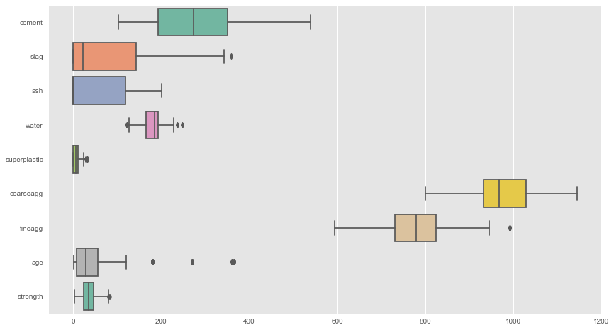

```python
plt.figure(figsize=(14,8))
sns.boxplot(data=dfconcrete, orient="h", palette="Set2", dodge=False)
```

##### Observation from Boxplots of the various attributes : From the above boxplot we can see that there are outliers in some columns. From the above ploting we can say slag, water, superplastic, fineagg and age column are having clear outliers. Let's see these plots separately. We will be finding the outliers counts in individual attributes analysis and fixing the outliers after visualization and analysis of each attribute.

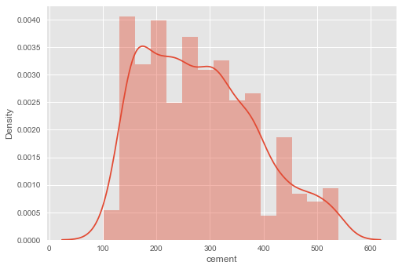

```python
sns.distplot(dfconcrete['cement'])
```

##### 'Cement' Distribution : From above distribution chart we can see that there are no outliers in cement column and it's looks quite close like a normally distributed. Cemennt values lies between range 100 to 500

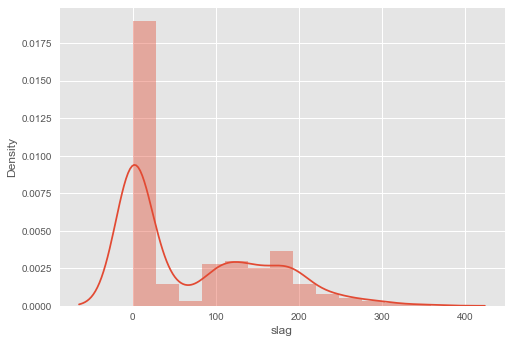

```python
sns.distplot(dfconcrete['slag'])
```

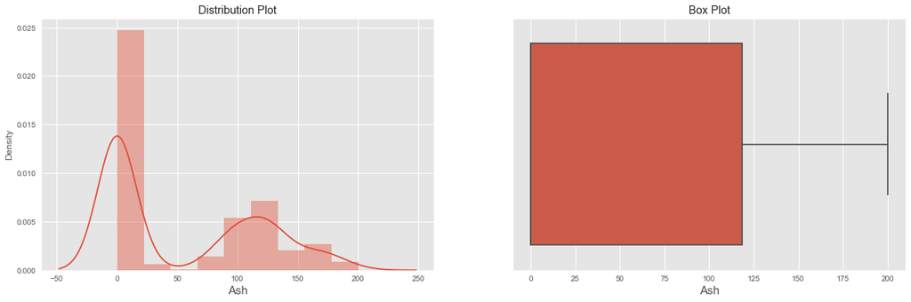

```python
## sns.distplot(dfconcrete['ash'])
fig, (ax1, ax2) = plt.subplots(nrows = 1, ncols = 2, figsize = (13, 5))
fig.set_size_inches(20,6)
sns.distplot(dfconcrete['ash'],ax=ax1)
ax1.set_xlabel('Ash', fontsize=15)
ax1.set_title("Distribution Plot")

sns.boxplot(dfconcrete['ash'],ax=ax2)
ax2.set_xlabel('Ash', fontsize=15)
ax2.set_title("Box Plot")
```

##### 'Ash' distribution: From above we can see that there are no outliers in ash column. We can see a tall tower at range of 0 to 20 with max of 200.

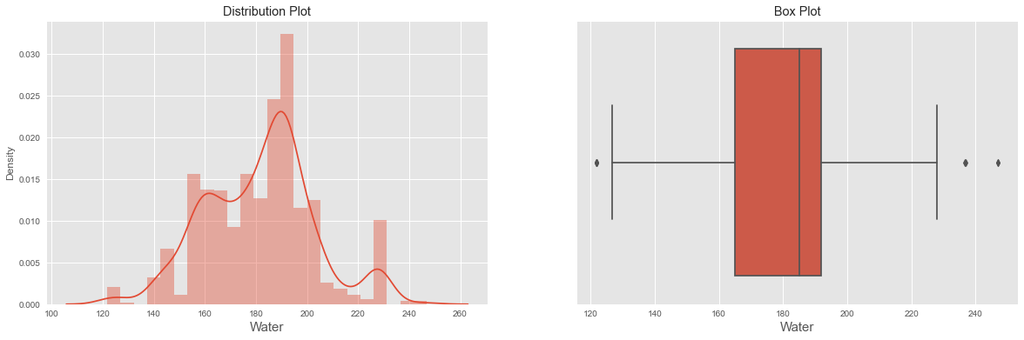

```python
## sns.distplot(dfconcrete['water'])
fig, (ax1, ax2) = plt.subplots(nrows = 1, ncols = 2, figsize = (13, 5))
fig.set_size_inches(20,6)
sns.distplot(dfconcrete['water'],ax=ax1)
ax1.set_xlabel('Water', fontsize=15)
ax1.set_title("Distribution Plot")

sns.boxplot(dfconcrete['water'],ax=ax2)
ax2.set_xlabel('Water', fontsize=15)
ax2.set_title("Box Plot")
```

##### As outliers are there in water so we will check how many outliers are there in the water.

```python
##outliers are there in the water.
outlier_columns = []

Q1 =  dfconcrete['water'].quantile(0.25) # 1st Quartile
Q3 =  dfconcrete['water'].quantile(0.75) # 3rd Quartile
IQR = Q3 - Q1                      # Interquartile range

LTV_water = Q1 - 1.75 * IQR   # lower bound
UTV_water = Q3 + 1.75 * IQR   # upper bound

print('Interquartile range = ', IQR)
print('water <',LTV_water ,'and >',UTV_water, ' are outliers')
print('Number of outliers in water column below the lower whisker =', dfconcrete[dfconcrete['water'] < (Q1-(1.75*IQR))]['water'].count())
print('Number of outliers in water column above the upper whisker =', dfconcrete[dfconcrete['water'] > (Q3+(1.75*IQR))]['water'].count())

# storing column name and upper-lower bound value where outliers are presense
outlier_columns.append('water')
upperLowerBound_Disct = {'water':UTV_water}
```

```
Interquartile range =  27.099999999999994
water < 117.47500000000002 and > 239.42499999999998  are outliers
Number of outliers in water column below the lower whisker = 0
Number of outliers in water column above the upper whisker = 2
```

##### There are 2 outliers in 'Water' column which we would need to replace with the median of Water data.

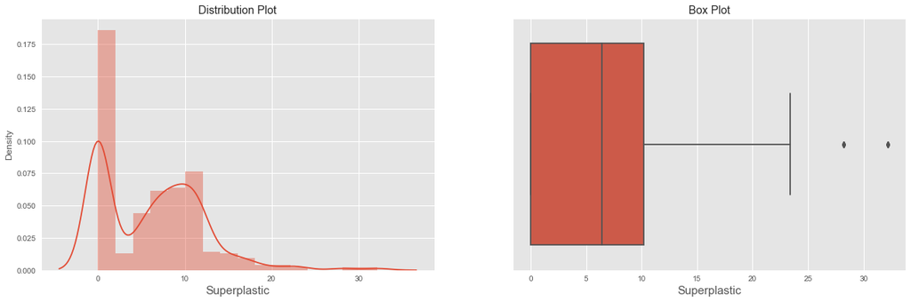

```python
## sns.distplot(dfconcrete['superplastic'])
fig, (ax1, ax2) = plt.subplots(nrows = 1, ncols = 2, figsize = (13, 5))
fig.set_size_inches(20,6)
sns.distplot(dfconcrete['superplastic'],ax=ax1)
ax1.set_xlabel('Superplastic', fontsize=15)
ax1.set_title("Distribution Plot")

sns.boxplot(dfconcrete['superplastic'],ax=ax2)
ax2.set_xlabel('Superplastic', fontsize=15)
ax2.set_title("Box Plot")
```

##### As outliers are there in superplastic so we will check how many outliers are there in the superplastic.

```python
Q1 =  dfconcrete['superplastic'].quantile(0.25) # 1º Quartile
Q3 =  dfconcrete['superplastic'].quantile(0.75) # 3º Quartile
IQR = Q3 - Q1                      # Interquartile range

LTV_superplastic = Q1 - 1.75 * IQR   # lower bound
UTV_superplastic = Q3 + 1.75 * IQR   # upper bound

print('Interquartile range = ', IQR)
print('superplastic <',LTV_superplastic ,'and >',UTV_superplastic, ' are outliers')
print('Numerber of outliers in superplastic column below the lower whisker =', dfconcrete[dfconcrete['superplastic'] < (Q1-(1.75*IQR))]['superplastic'].count())
print('Numerber of outliers in superplastic column above the upper whisker =', dfconcrete[dfconcrete['superplastic'] > (Q3+(1.75*IQR))]['superplastic'].count())

# storing column name and upper-lower bound value where outliers are presense
outlier_columns.append('superplastic')
upperLowerBound_Disct['superplastic'] = UTV_superplastic
```

```
Interquartile range =  10.2
superplastic < -17.849999999999998 and > 28.049999999999997  are outliers
Numerber of outliers in superplastic column below the lower whisker = 0
Numerber of outliers in superplastic column above the upper whisker = 10
```

##### As can be seen per the above query's output we have 10 outliers on the upper side of 'Superplastic' data column.

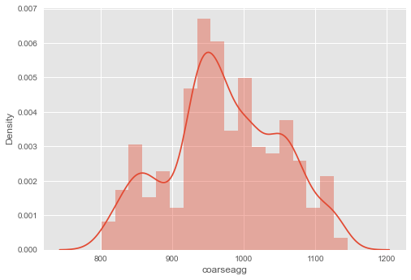

```python
sns.distplot(dfconcrete['coarseagg'])
```

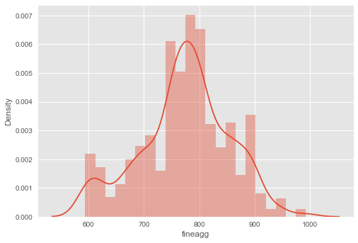

```python
sns.distplot(dfconcrete['fineagg'])
```

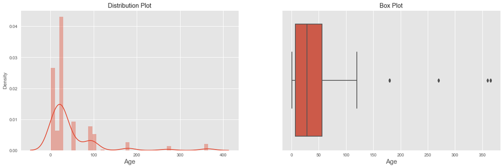

```python
## sns.distplot(dfconcrete['age'])
fig, (ax1, ax2) = plt.subplots(nrows = 1, ncols = 2, figsize = (13, 5))
fig.set_size_inches(20,6)
sns.distplot(dfconcrete['age'],ax=ax1)
ax1.set_xlabel('Age', fontsize=15)
ax1.set_title("Distribution Plot")

sns.boxplot(dfconcrete['age'],ax=ax2)
ax2.set_xlabel('Age', fontsize=15)
ax2.set_title("Box Plot")
```

##### 'Age' distribution : From above we can see that there are many outliers in Age column and there is right skewness because long tail is at right side(mean>median).

##### As outliers are there in 'Age' attribut therefore we will check how many outliers are there in the 'Age' column.

```python
Q1 =  dfconcrete['age'].quantile(0.25) # 1st Quartile
Q3 =  dfconcrete['age'].quantile(0.75) # 3rd Quartile
IQR = Q3 - Q1                      # Interquartile range

LTV_age = Q1 - 1.75 * IQR   # lower bound
UTV_age = Q3 + 1.75 * IQR   # upper bound

print('Interquartile range = ', IQR)
print('age <',LTV_age ,'and >',UTV_age, ' are outliers')
print('Number of outliers in age column below the lower whisker =', dfconcrete[dfconcrete['age'] < (Q1-(1.75*IQR))]['age'].count())
print('Number of outliers in age column above the upper whisker =', dfconcrete[dfconcrete['age'] > (Q3+(1.75*IQR))]['age'].count())

# storing column name and upper-lower bound value where outliers are presense
outlier_columns.append('age')
upperLowerBound_Disct['age'] = UTV_age
```

```
Interquartile range =  49.0
age < -78.75 and > 141.75  are outliers
Number of outliers in age column below the lower whisker = 0
Number of outliers in age column above the upper whisker = 59
```

##### There are 59 outliers on the right / upper side of 'Age' column. We will replace these outliers with the median of 'Age' data.

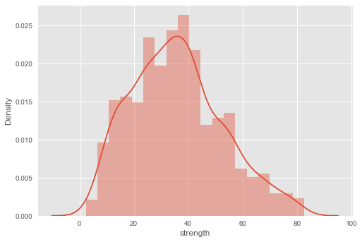

```python
sns.distplot(dfconcrete['strength'])
```

### Fixing Outliers

##### As we have seen above outlier are present in the given dataset. There are multiple ways to deal with outliers but we mostly prefer either to drop the outliers or repalce it with median/mean.

##### Since there is not too much data given to begin with so dropping rows with outliers will only make the data set that much poorer. Therefore we will replace the outliers with median and this way we will not lose some important information.

##### I have also shown the number of outliers presence in each column in below code.

```python
print('These are the columns which have outliers : \n\n',outlier_columns)
print('\n\n',upperLowerBound_Disct)
```

```
These are the columns which have outliers :

 ['water', 'superplastic', 'age']


 {'water': 239.42499999999998, 'superplastic': 28.049999999999997, 'age': 141.75}
```

```python
dfconcrete_new = dfconcrete.copy()
```

```python
dfconcrete_new.head()
```

|  | cement | slag | ash | water | superplastic | coarseagg | fineagg | age | strength |
| --- | --- | --- | --- | --- | --- | --- | --- | --- | --- |
| 0 | 141.30 | 212.00 | 0.00 | 203.50 | 0.00 | 971.80 | 748.50 | 28 | 29.89 |
| 1 | 168.90 | 42.20 | 124.30 | 158.30 | 10.80 | 1,080.80 | 796.20 | 14 | 23.51 |
| 2 | 250.00 | 0.00 | 95.70 | 187.40 | 5.50 | 956.90 | 861.20 | 28 | 29.22 |
| 3 | 266.00 | 114.00 | 0.00 | 228.00 | 0.00 | 932.00 | 670.00 | 28 | 45.85 |
| 4 | 154.80 | 183.40 | 0.00 | 193.30 | 9.10 | 1,047.40 | 696.70 | 28 | 18.29 |

#### Here below we are replacing the outliers with the corresponding column's median

```python
for col_name in dfconcrete_new.columns[:-1]:
    q1 = dfconcrete_new[col_name].quantile(0.25)
    q3 = dfconcrete_new[col_name].quantile(0.75)
    iqr = q3 - q1
    low = q1-1.75*iqr
    high = q3+1.75*iqr

    dfconcrete_new.loc[(dfconcrete_new[col_name] < low) | (dfconcrete_new[col_name] > high), col_name] = dfconcrete_new[col_name].median()
```

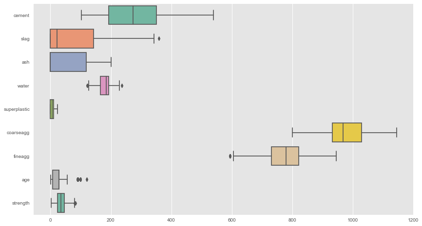

```python
plt.figure(figsize=(14,8))
sns.boxplot(data=dfconcrete_new, orient="h", palette="Set2", dodge=False)
```

```python
dfconcrete_new.describe().transpose()
```

|  | count | mean | std | min | 25% | 50% | 75% | max |
| --- | --- | --- | --- | --- | --- | --- | --- | --- |
| cement | 1,030.00 | 281.17 | 104.51 | 102.00 | 192.38 | 272.90 | 350.00 | 540.00 |
| slag | 1,030.00 | 73.90 | 86.28 | 0.00 | 0.00 | 22.00 | 142.95 | 359.40 |
| ash | 1,030.00 | 54.19 | 64.00 | 0.00 | 0.00 | 0.00 | 118.30 | 200.10 |
| water | 1,030.00 | 181.45 | 21.16 | 121.80 | 164.90 | 185.00 | 192.00 | 237.00 |
| superplastic | 1,030.00 | 5.97 | 5.48 | 0.00 | 0.00 | 6.40 | 10.07 | 23.40 |
| coarseagg | 1,030.00 | 972.92 | 77.75 | 801.00 | 932.00 | 968.00 | 1,029.40 | 1,145.00 |
| fineagg | 1,030.00 | 772.55 | 78.70 | 594.00 | 730.95 | 779.40 | 822.20 | 945.00 |
| age | 1,030.00 | 32.26 | 27.80 | 1.00 | 7.00 | 28.00 | 28.00 | 120.00 |
| strength | 1,030.00 | 35.82 | 16.71 | 2.33 | 23.71 | 34.45 | 46.14 | 82.60 |

[output not shown]

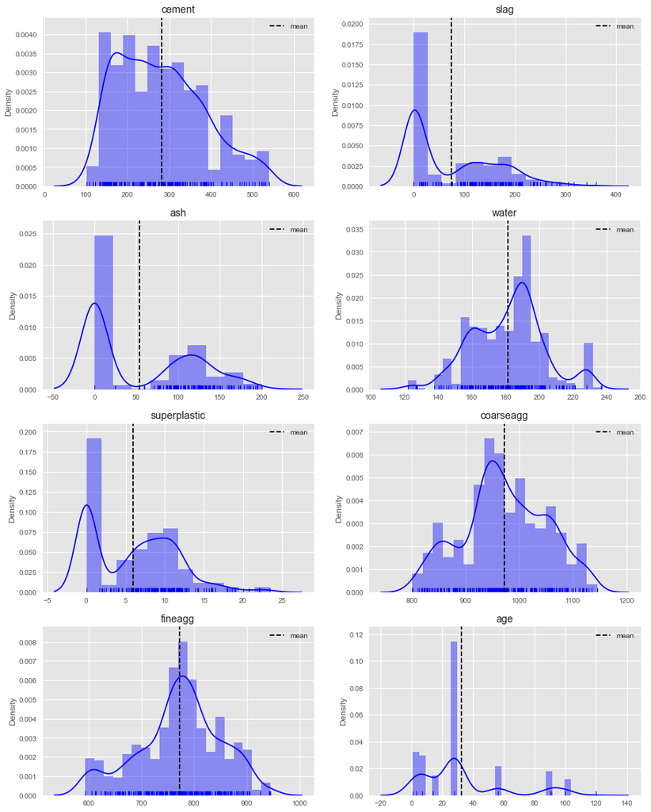

```python
import itertools

cols = [i for i in dfconcrete_new.columns if i != 'strength']

fig = plt.figure(figsize=(15, 20))

for i,j in itertools.zip_longest(cols, range(len(cols))):
    plt.subplot(4,2,j+1)
    ax = sns.distplot(dfconcrete_new[i],color='blue',rug=True)
    plt.axvline(dfconcrete_new[i].mean(),linestyle="dashed",label="mean", color='black')
    plt.legend()
    plt.title(i)
    plt.xlabel("")
```

## 2. Bi-variate Analysis

```python
dfconcrete_new.head()
```

|  | cement | slag | ash | water | superplastic | coarseagg | fineagg | age | strength |
| --- | --- | --- | --- | --- | --- | --- | --- | --- | --- |
| 0 | 141.30 | 212.00 | 0.00 | 203.50 | 0.00 | 971.80 | 748.50 | 28 | 29.89 |
| 1 | 168.90 | 42.20 | 124.30 | 158.30 | 10.80 | 1,080.80 | 796.20 | 14 | 23.51 |
| 2 | 250.00 | 0.00 | 95.70 | 187.40 | 5.50 | 956.90 | 861.20 | 28 | 29.22 |
| 3 | 266.00 | 114.00 | 0.00 | 228.00 | 0.00 | 932.00 | 670.00 | 28 | 45.85 |
| 4 | 154.80 | 183.40 | 0.00 | 193.30 | 9.10 | 1,047.40 | 696.70 | 28 | 18.29 |

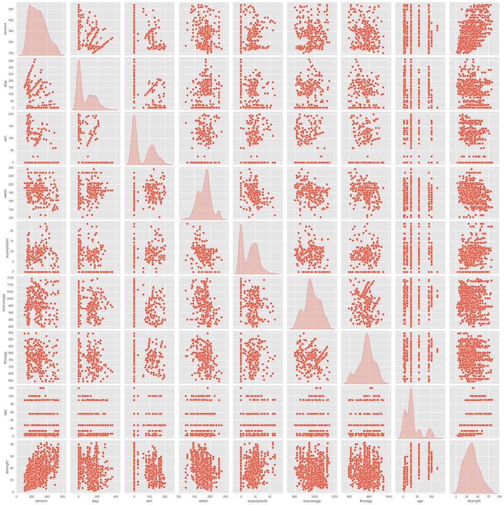

```python
sns.pairplot(dfconcrete_new,diag_kind='kde')
plt.show()
```

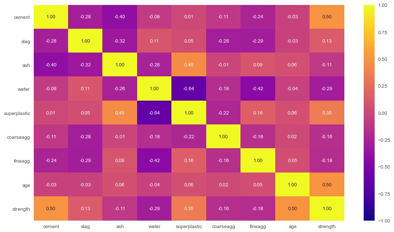

```python
plt.figure(figsize=(14,8))
sns.heatmap(dfconcrete_new.corr(),vmin=-1, cmap='plasma',annot=True, fmt='.2f')
```

#### Based on the Heatmap above:

##### Superplastic - Strenght: High positive correlation of 0.35 is observed between superplastic and the strength of the concrete.

##### Superplastic - water: A very high negative correlation of -0.64 is seen betwem superplastic and water

##### Coarseagg - Stremgth: A relatively less negatve correlation of of -0.16 is observed between coarseagg and Strenght of concrete

##### Fineagg - Strenght: A relatively less negatve correlation of of -0.18 is observed between fineagg and Strenght of concrete

#### Bucketing columns which have a high correaltion with strength. Bucketing 'Cement', 'Water', 'Age'

```python
dfconcrete_grp = dfconcrete_new.copy()
```

```python
#Bucketing the 'Strength' column:
bins = [0, 20, 40, 60, 85]
dfconcrete_grp['strength_grp'] = pd.cut(dfconcrete_grp['strength'], bins)
print (dfconcrete_grp)
```

```
      cement   slag    ash  water  superplastic  coarseagg  fineagg  age  \
0     141.30 212.00   0.00 203.50          0.00     971.80   748.50   28
1     168.90  42.20 124.30 158.30         10.80   1,080.80   796.20   14
2     250.00   0.00  95.70 187.40          5.50     956.90   861.20   28
3     266.00 114.00   0.00 228.00          0.00     932.00   670.00   28
4     154.80 183.40   0.00 193.30          9.10   1,047.40   696.70   28
...      ...    ...    ...    ...           ...        ...      ...  ...
1025  135.00   0.00 166.00 180.00         10.00     961.00   805.00   28
1026  531.30   0.00   0.00 141.80          6.40     852.10   893.70    3
1027  276.40 116.00  90.30 179.60          8.90     870.10   768.30   28
1028  342.00  38.00   0.00 228.00          0.00     932.00   670.00   28
1029  540.00   0.00   0.00 173.00          0.00   1,125.00   613.00    7

      strength strength_grp
0        29.89     (20, 40]
1        23.51     (20, 40]
2        29.22     (20, 40]
3        45.85     (40, 60]
4        18.29      (0, 20]
...        ...          ...
1025     13.29      (0, 20]
1026     41.30     (40, 60]
1027     44.28     (40, 60]
1028     55.06     (40, 60]
1029     52.61     (40, 60]

[1030 rows x 10 columns]
```

```python
#Bucketing the 'Cement' column:
bins = [100, 200, 300, 400, 500, 600]
dfconcrete_grp['cement_grp'] = pd.cut(dfconcrete_grp['cement'], bins)
print (dfconcrete_grp)
```

```
      cement   slag    ash  water  superplastic  coarseagg  fineagg  age  \
0     141.30 212.00   0.00 203.50          0.00     971.80   748.50   28
1     168.90  42.20 124.30 158.30         10.80   1,080.80   796.20   14
2     250.00   0.00  95.70 187.40          5.50     956.90   861.20   28
3     266.00 114.00   0.00 228.00          0.00     932.00   670.00   28
4     154.80 183.40   0.00 193.30          9.10   1,047.40   696.70   28
...      ...    ...    ...    ...           ...        ...      ...  ...
1025  135.00   0.00 166.00 180.00         10.00     961.00   805.00   28
1026  531.30   0.00   0.00 141.80          6.40     852.10   893.70    3
1027  276.40 116.00  90.30 179.60          8.90     870.10   768.30   28
1028  342.00  38.00   0.00 228.00          0.00     932.00   670.00   28
1029  540.00   0.00   0.00 173.00          0.00   1,125.00   613.00    7

      strength strength_grp  cement_grp
0        29.89     (20, 40]  (100, 200]
1        23.51     (20, 40]  (100, 200]
2        29.22     (20, 40]  (200, 300]
3        45.85     (40, 60]  (200, 300]
4        18.29      (0, 20]  (100, 200]
...        ...          ...         ...
1025     13.29      (0, 20]  (100, 200]
1026     41.30     (40, 60]  (500, 600]
1027     44.28     (40, 60]  (200, 300]
1028     55.06     (40, 60]  (300, 400]
1029     52.61     (40, 60]  (500, 600]

[1030 rows x 11 columns]
```

```python
#Bucketing the 'Age' column:
bins = [0, 10, 20, 30, 40, 50, 60]
dfconcrete_grp['age_grp'] = pd.cut(dfconcrete_grp['age'], bins)
print (dfconcrete_grp)
```

```
      cement   slag    ash  water  superplastic  coarseagg  fineagg  age  \
0     141.30 212.00   0.00 203.50          0.00     971.80   748.50   28
1     168.90  42.20 124.30 158.30         10.80   1,080.80   796.20   14
2     250.00   0.00  95.70 187.40          5.50     956.90   861.20   28
3     266.00 114.00   0.00 228.00          0.00     932.00   670.00   28
4     154.80 183.40   0.00 193.30          9.10   1,047.40   696.70   28
...      ...    ...    ...    ...           ...        ...      ...  ...
1025  135.00   0.00 166.00 180.00         10.00     961.00   805.00   28
1026  531.30   0.00   0.00 141.80          6.40     852.10   893.70    3
1027  276.40 116.00  90.30 179.60          8.90     870.10   768.30   28
1028  342.00  38.00   0.00 228.00          0.00     932.00   670.00   28
1029  540.00   0.00   0.00 173.00          0.00   1,125.00   613.00    7

      strength strength_grp  cement_grp   age_grp
0        29.89     (20, 40]  (100, 200]  (20, 30]
1        23.51     (20, 40]  (100, 200]  (10, 20]
2        29.22     (20, 40]  (200, 300]  (20, 30]
3        45.85     (40, 60]  (200, 300]  (20, 30]
4        18.29      (0, 20]  (100, 200]  (20, 30]
...        ...          ...         ...       ...
1025     13.29      (0, 20]  (100, 200]  (20, 30]
1026     41.30     (40, 60]  (500, 600]   (0, 10]
1027     44.28     (40, 60]  (200, 300]  (20, 30]
1028     55.06     (40, 60]  (300, 400]  (20, 30]
1029     52.61     (40, 60]  (500, 600]   (0, 10]

[1030 rows x 12 columns]
```

```python
#Bucketing the 'Water' column:
bins = [120, 140, 160, 180, 200, 220, 240]
dfconcrete_grp['water_grp'] = pd.cut(dfconcrete_grp['water'], bins)
print (dfconcrete_grp)
```

```
      cement   slag    ash  water  superplastic  coarseagg  fineagg  age  \
0     141.30 212.00   0.00 203.50          0.00     971.80   748.50   28
1     168.90  42.20 124.30 158.30         10.80   1,080.80   796.20   14
2     250.00   0.00  95.70 187.40          5.50     956.90   861.20   28
3     266.00 114.00   0.00 228.00          0.00     932.00   670.00   28
4     154.80 183.40   0.00 193.30          9.10   1,047.40   696.70   28
...      ...    ...    ...    ...           ...        ...      ...  ...
1025  135.00   0.00 166.00 180.00         10.00     961.00   805.00   28
1026  531.30   0.00   0.00 141.80          6.40     852.10   893.70    3
1027  276.40 116.00  90.30 179.60          8.90     870.10   768.30   28
1028  342.00  38.00   0.00 228.00          0.00     932.00   670.00   28
1029  540.00   0.00   0.00 173.00          0.00   1,125.00   613.00    7

      strength strength_grp  cement_grp   age_grp   water_grp
0        29.89     (20, 40]  (100, 200]  (20, 30]  (200, 220]
1        23.51     (20, 40]  (100, 200]  (10, 20]  (140, 160]
2        29.22     (20, 40]  (200, 300]  (20, 30]  (180, 200]
3        45.85     (40, 60]  (200, 300]  (20, 30]  (220, 240]
4        18.29      (0, 20]  (100, 200]  (20, 30]  (180, 200]
...        ...          ...         ...       ...         ...
1025     13.29      (0, 20]  (100, 200]  (20, 30]  (160, 180]
1026     41.30     (40, 60]  (500, 600]   (0, 10]  (140, 160]
1027     44.28     (40, 60]  (200, 300]  (20, 30]  (160, 180]
1028     55.06     (40, 60]  (300, 400]  (20, 30]  (220, 240]
1029     52.61     (40, 60]  (500, 600]   (0, 10]  (160, 180]

[1030 rows x 13 columns]
```

```python
#Bucketing the 'Superplastic' column:
bins = [0, 5, 10, 15, 20, 25]
dfconcrete_grp['superplastic_grp'] = pd.cut(dfconcrete_grp['superplastic'], bins)
print (dfconcrete_grp)
```

```
      cement   slag    ash  water  superplastic  coarseagg  fineagg  age  \
0     141.30 212.00   0.00 203.50          0.00     971.80   748.50   28
1     168.90  42.20 124.30 158.30         10.80   1,080.80   796.20   14
2     250.00   0.00  95.70 187.40          5.50     956.90   861.20   28
3     266.00 114.00   0.00 228.00          0.00     932.00   670.00   28
4     154.80 183.40   0.00 193.30          9.10   1,047.40   696.70   28
...      ...    ...    ...    ...           ...        ...      ...  ...
1025  135.00   0.00 166.00 180.00         10.00     961.00   805.00   28
1026  531.30   0.00   0.00 141.80          6.40     852.10   893.70    3
1027  276.40 116.00  90.30 179.60          8.90     870.10   768.30   28
1028  342.00  38.00   0.00 228.00          0.00     932.00   670.00   28
1029  540.00   0.00   0.00 173.00          0.00   1,125.00   613.00    7

      strength strength_grp  cement_grp   age_grp   water_grp superplastic_grp
0        29.89     (20, 40]  (100, 200]  (20, 30]  (200, 220]              NaN
1        23.51     (20, 40]  (100, 200]  (10, 20]  (140, 160]     (10.0, 15.0]
2        29.22     (20, 40]  (200, 300]  (20, 30]  (180, 200]      (5.0, 10.0]
3        45.85     (40, 60]  (200, 300]  (20, 30]  (220, 240]              NaN
4        18.29      (0, 20]  (100, 200]  (20, 30]  (180, 200]      (5.0, 10.0]
...        ...          ...         ...       ...         ...              ...
1025     13.29      (0, 20]  (100, 200]  (20, 30]  (160, 180]      (5.0, 10.0]
1026     41.30     (40, 60]  (500, 600]   (0, 10]  (140, 160]      (5.0, 10.0]
1027     44.28     (40, 60]  (200, 300]  (20, 30]  (160, 180]      (5.0, 10.0]
1028     55.06     (40, 60]  (300, 400]  (20, 30]  (220, 240]              NaN
1029     52.61     (40, 60]  (500, 600]   (0, 10]  (160, 180]              NaN

[1030 rows x 14 columns]
```

### 2a. Bi-variate analysis between the predictor variables and target column.

#### In this section we will attempt to check the correlation of an independent attribute on another especially on 'Strength' dependent variable

##### Cement Vs Strength

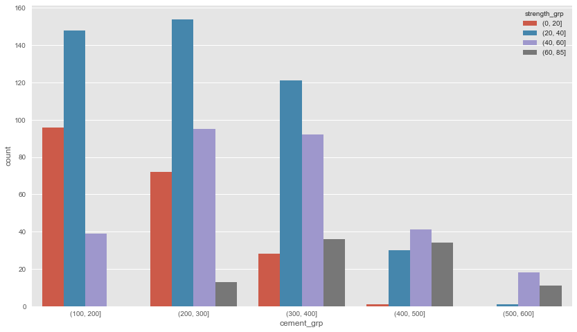

```python
plt.figure(figsize=(14,8))
sns.countplot(x="cement_grp", data=dfconcrete_grp, hue="strength_grp")
```

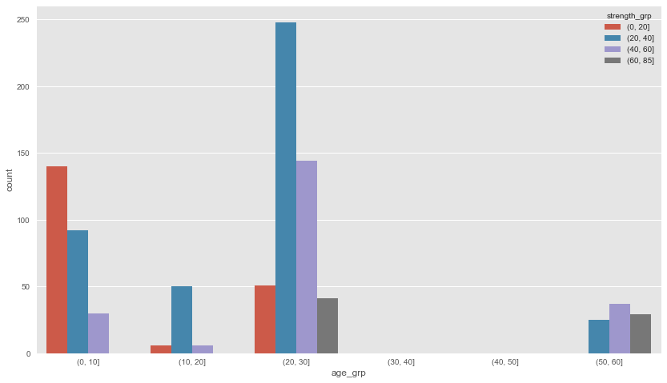

```python
plt.figure(figsize=(14,8))
sns.countplot(x="age_grp", data=dfconcrete_grp, hue="strength_grp")
```

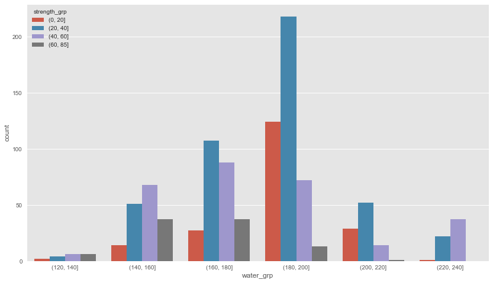

```python
plt.figure(figsize=(14,8))
sns.countplot(x="water_grp", data=dfconcrete_grp, hue="strength_grp")
```

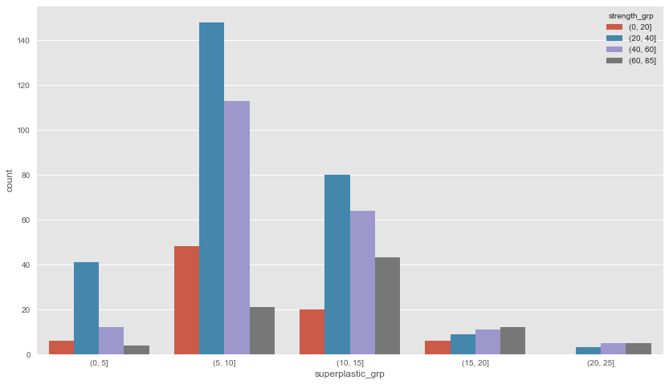

```python
plt.figure(figsize=(14,8))
sns.countplot(x="superplastic_grp", data=dfconcrete_grp, hue="strength_grp")
```

## 3. Feature Engineering techniques

### 3.1 Identify Opportunities (if any) to extract new features from existing features, drop a feature(if required)

##### Based on the correlation related observations as drwan from the heatmap and the subsequent countplots we can conclude that the following features have a significant impact on the outcome of the concrete's strength compared to other featues. These featues are whose variation we have observed vis-a-vis that of concrete's strength are:

##### 1.'Water',

##### 2. 'Cement'

##### 3. 'Age',

##### 4. 'Superplastic',

##### 5. 'Coarse Aggregate' and

##### 6. 'Fine aggregate'

##### We can draw additional functions / features that may impact the dependent i.e. the Strength of the concrete based on the cobination of these features driven by the analysis of the given data.

#### Add new functions:

##### 1. Water to Cement ratio

##### 2. Coarse Aggregate to Fine Aggregate ratio

### Adding new features

```python
##df = df.add( df2, fill_value=0 )
## df['Col3'] = (df['Col2'] <= 1).astype(int)
## dfconcrete_new['cement'] = (df['Col2'] <= 1).astype(int)
dfconcrete_new['water-cement']=(dfconcrete_new['water']/dfconcrete_new['cement'])
dfconcrete_new['coarse-fine']=(dfconcrete_new['coarseagg']/dfconcrete_new['fineagg'])
```

```python
dfconcrete_new.head()
```

|  | cement | slag | ash | water | superplastic | coarseagg | fineagg | age | strength | water-cement | coarse-fine |
| --- | --- | --- | --- | --- | --- | --- | --- | --- | --- | --- | --- |
| 0 | 141.30 | 212.00 | 0.00 | 203.50 | 0.00 | 971.80 | 748.50 | 28 | 29.89 | 1.44 | 1.30 |
| 1 | 168.90 | 42.20 | 124.30 | 158.30 | 10.80 | 1,080.80 | 796.20 | 14 | 23.51 | 0.94 | 1.36 |
| 2 | 250.00 | 0.00 | 95.70 | 187.40 | 5.50 | 956.90 | 861.20 | 28 | 29.22 | 0.75 | 1.11 |
| 3 | 266.00 | 114.00 | 0.00 | 228.00 | 0.00 | 932.00 | 670.00 | 28 | 45.85 | 0.86 | 1.39 |
| 4 | 154.80 | 183.40 | 0.00 | 193.30 | 9.10 | 1,047.40 | 696.70 | 28 | 18.29 | 1.25 | 1.50 |

```python
dfconcrete_new.info()
```

```
<class 'pandas.core.frame.DataFrame'>
RangeIndex: 1030 entries, 0 to 1029
Data columns (total 11 columns):
 #   Column        Non-Null Count  Dtype
---  ------        --------------  -----
 0   cement        1030 non-null   float64
 1   slag          1030 non-null   float64
 2   ash           1030 non-null   float64
 3   water         1030 non-null   float64
 4   superplastic  1030 non-null   float64
 5   coarseagg     1030 non-null   float64
 6   fineagg       1030 non-null   float64
 7   age           1030 non-null   int64
 8   strength      1030 non-null   float64
 9   water-cement  1030 non-null   float64
 10  coarse-fine   1030 non-null   float64
dtypes: float64(10), int64(1)
memory usage: 88.6 KB
```

### 3.2. Get the data model ready and do a train test split.

```python
dfconcrete_new['strength'] = dfconcrete_new['strength'].astype(np.int64)
```

```python
dfconcrete_new.info()
```

```
<class 'pandas.core.frame.DataFrame'>
RangeIndex: 1030 entries, 0 to 1029
Data columns (total 11 columns):
 #   Column        Non-Null Count  Dtype
---  ------        --------------  -----
 0   cement        1030 non-null   float64
 1   slag          1030 non-null   float64
 2   ash           1030 non-null   float64
 3   water         1030 non-null   float64
 4   superplastic  1030 non-null   float64
 5   coarseagg     1030 non-null   float64
 6   fineagg       1030 non-null   float64
 7   age           1030 non-null   int64
 8   strength      1030 non-null   int64
 9   water-cement  1030 non-null   float64
 10  coarse-fine   1030 non-null   float64
dtypes: float64(9), int64(2)
memory usage: 88.6 KB
```

```python
# Split Train/Test data 70:30 ratio
from sklearn.model_selection import train_test_split

y = dfconcrete_new['strength']
X = dfconcrete_new.loc[:, dfconcrete_new.columns != 'strength']

X_train, X_test, y_train, y_test = train_test_split (X, y, test_size=0.3, random_state=42,)
X_train.shape, X_test.shape, y_train.shape, y_test.shape
```

```
((721, 10), (309, 10), (721,), (309,))
```

### 3.3 3. Decide on the complexity of the model

### Linear Regression

```python
# Defining the kFold function for the cross validation
n_split = 10
rand_state = 7
kfold = KFold(n_split, random_state = rand_state)
linear_model = []
linear_model_score = []
linear_model_RMSE = []
linear_model_R_2 = []
Model = []
RMSE = []
R_sq = []
```

```python
regression_model = LinearRegression()
regression_model.fit(X_train, y_train)
linear_model.append('Linear Regression')

lr_score = regression_model.score(X_test, y_test)
linear_model_score.append(lr_score)
print("Linear Regression Model Score:",lr_score)

lr_rmse = np.sqrt((-1) * cross_val_score(regression_model, X_train, y_train.values.ravel(), cv=kfold, scoring='neg_mean_squared_error').mean())
print("Linear Regression Model RMSE :", lr_rmse)

linear_model_RMSE.append(lr_rmse)

lr_r2 = cross_val_score(regression_model, X_train, y_train.values.ravel(), cv=kfold, scoring='r2').mean()
print("Linear Regression Model R-Square Value :",lr_r2)


linear_model_R_2.append(lr_r2)
```

```
Linear Regression Model Score: 0.705307116483626
Linear Regression Model RMSE : 9.122311730762066
Linear Regression Model R-Square Value : 0.6992417779674256
```

### Polynomial Regression - Degree 2 :

```python
#class sklearn.preprocessing.PolynomialFeatures(degree=2, *, interaction_only=False, include_bias=True, order='C')
poly = PolynomialFeatures(degree=2, interaction_only=True)
X_train_ = poly.fit_transform(X_train)
X_test_ = poly.fit_transform(X_test)
print("Shape", X_train_.shape)
linear_model.append('Polynomial Features - 2D')

poly_clf = LinearRegression()

poly_clf.fit(X_train_, y_train)

pf_score = poly_clf.score(X_test_, y_test)
print("2D Polynomial Model Score:",pf_score)
linear_model_score.append(pf_score)

pf_rmse = np.sqrt((-1) * cross_val_score(poly_clf, X_train_, y_train.values.ravel(), cv=kfold, scoring='neg_mean_squared_error').mean())
print("2D Polynomial Model RMSE :", pf_rmse)
linear_model_RMSE.append(pf_rmse)

pf_r2 = cross_val_score(poly_clf, X_train_, y_train.values.ravel(), cv=kfold, scoring='r2').mean()
linear_model_R_2.append(pf_r2)
print("2D Polynomial Model R-Square Value :", pf_r2)
```

```
Shape (721, 56)
2D Polynomial Model Score: 0.7194185414901457
2D Polynomial Model RMSE : 8.245701352539179
2D Polynomial Model R-Square Value : 0.7587203958809094
```

### Polynomial Regression - Degree 3 :

```python
poly = PolynomialFeatures(degree=3, interaction_only=True)
X_train__ = poly.fit_transform(X_train)
X_test__ = poly.fit_transform(X_test)
print("Shape", X_train__.shape)
linear_model.append('Polynomial Features - 3D')

poly_clf_3d = LinearRegression()

poly_clf_3d.fit(X_train__, y_train)

pf3_score = poly_clf_3d.score(X_test__, y_test)
print("3D Polynomial Model Score:",pf3_score)
linear_model_score.append(pf3_score)

pf3_rmse = np.sqrt((-1) * cross_val_score(poly_clf_3d, X_train__, y_train.values.ravel(), cv=kfold, scoring='neg_mean_squared_error').mean())
print("3D Polynomial Model RMSE :",pf3_rmse)
linear_model_RMSE.append(pf3_rmse)

pf3_r2 = cross_val_score(poly_clf_3d, X_train__, y_train.values.ravel(), cv=kfold, scoring='r2').mean()
print("3D Polynomial Model R-Square Value :",pf3_r2)
linear_model_R_2.append(pf3_r2)
```

```
Shape (721, 176)
3D Polynomial Model Score: 0.6646149312612657
3D Polynomial Model RMSE : 9.819586995932662
3D Polynomial Model R-Square Value : 0.6611118094480156
```

#### Compare the performance of single degree, two degree and three degree Linear Regression in the below matrix:

```python
compare_lr_model_df = pd.DataFrame({'Model': linear_model,
                           'Score': linear_model_score,
                           'RMSE': linear_model_RMSE,
                           'R Squared': linear_model_R_2})
compare_lr_model_df
```

|  | Model | Score | RMSE | R Squared |
| --- | --- | --- | --- | --- |
| 0 | Linear Regression | 0.71 | 9.12 | 0.70 |
| 1 | Polynomial Features - 2D | 0.72 | 8.25 | 0.76 |
| 2 | Polynomial Features - 3D | 0.66 | 9.82 | 0.66 |

#### Since Polynomial of Degree 2 has highest accuracy of 0.72 and highest R Squared of 0.76 alongiwht minimm RMSE of 8.25 therefore Polynomial with Degree 2 is the best model.

## • Creating the Model and Tuning It

```python
dff=pd.get_dummies(dfconcrete, drop_first=True)
```

```python
dff.shape
```

```
(1030, 9)
```

```python
dff.info()
```

[output not shown]

```python
# Lets check for highly correlated variables
cor= dff.corr()
cor.loc[:,:] = np.tril(cor,k=-1)
cor=cor.stack()
cor[(cor > 0.8) | (cor< -0.8)]
```

```
Series([], dtype: float64)
```

```python
# Split Train/Test data 70:30 ratio
from sklearn.model_selection import train_test_split

y = dff['strength']
X = dff.loc[:, dff.columns != 'strength']

X_train, X_test, y_train, y_test = train_test_split (X, y, test_size=0.3, random_state=42,)
X_train.shape, X_test.shape, y_train.shape, y_test.shape
```

```
((721, 8), (309, 8), (721,), (309,))
```

#### Random Forest Regressor Model

```python
rf=RandomForestRegressor(n_estimators=50,criterion='mse',max_features='auto',n_jobs=2,random_state=24)
rfm=rf.fit(X_train, y_train)
```

```python
##preds = rf.predict_proba(X_test)[:,1]
y_pred=rf.predict(X_test)
```

```python
# performance on train data
print('Performance on training data using RF:',rf.score(X_train,y_train))
# performance on test data
print('Performance on testing data using RF:',rf.score(X_test,y_test))
#Evaluate the model using accuracy
acc_RF=metrics.r2_score(y_test, y_pred)
print('Accuracy RF: ',acc_RF)
print('MSE: ',metrics.mean_squared_error(y_test, y_pred))
```

```
Performance on training data using RF: 0.9819204920943772
Performance on testing data using RF: 0.902874285975637
Accuracy RF:  0.902874285975637
MSE:  25.858119991643367
```

```python
#Store the accuracy results for each model in a dataframe for final comparison
results = pd.DataFrame({'Method':['Random Forest Regressor'], 'accuracy': acc_RF},index={'1'})
results = results[['Method', 'accuracy']]
results
```

|  | Method | accuracy |
| --- | --- | --- |
| 1 | Random Forest Regressor | 0.90 |

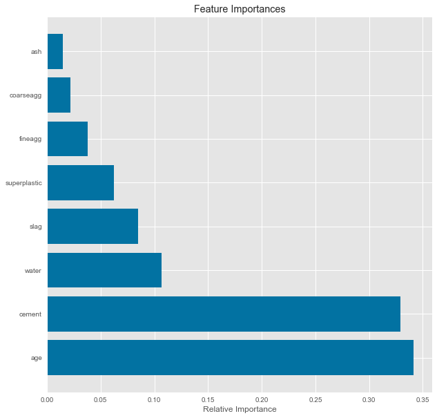

```python
# View a list of the features and their importance scores
importances = rf.feature_importances_
indices = np.argsort(importances)[::-1][:15]
a = dff.columns[:]
features= a.drop('strength',1)
#plot it
plt.figure(figsize=(10,10))
plt.title('Feature Importances')
plt.barh(range(len(indices)), importances[indices], color='b', align='center')
plt.yticks(range(len(indices)), features[indices])
plt.xlabel('Relative Importance')
plt.show()
```

#### As seen from above figure following os the order of impact of various attributes in influencing 'Strength' of concrete in decending order: Age > Cement > Water > Slag > Superplastic > Fineagg > Coarseagg > Ash

### K Fold Validation for Random Forest Regressor

```python
num_folds = 18
seed = 77
kfold = KFold(n_splits=num_folds, random_state=seed)
results1 = cross_val_score(rf,X, y, cv=kfold)
accuracy=np.mean(abs(results1))
print('Average accuracy: ',accuracy)
print('Standard Deviation: ',results1.std())
```

```
Average accuracy:  0.9216001393088502
Standard Deviation:  0.02786427555953602
```

```python
#Store the accuracy results for each model in a dataframe for final comparison
tempResultsDf = pd.DataFrame({'Method':['Random Forest Regressor K fold'], 'accuracy': [accuracy]},index={'2'})
results = pd.concat([results, tempResultsDf])
results = results[['Method', 'accuracy']]
results
```

|  | Method | accuracy |
| --- | --- | --- |
| 1 | Random Forest Regressor | 0.90 |
| 2 | Random Forest Regressor K fold | 0.92 |

### Gradient Boosting Regressor

```python
model=GradientBoostingRegressor()
model.fit(X_train, y_train)
```

```
GradientBoostingRegressor(alpha=0.9, ccp_alpha=0.0, criterion='friedman_mse',
                          init=None, learning_rate=0.1, loss='ls', max_depth=3,
                          max_features=None, max_leaf_nodes=None,
                          min_impurity_decrease=0.0, min_impurity_split=None,
                          min_samples_leaf=1, min_samples_split=2,
                          min_weight_fraction_leaf=0.0, n_estimators=100,
                          n_iter_no_change=None, presort='deprecated',
                          random_state=None, subsample=1.0, tol=0.0001,
                          validation_fraction=0.1, verbose=0, warm_start=False)
```

```python
y_pred = model.predict(X_test)
# performance on train data
print('Performance on training data using GBR:',model.score(X_train,y_train))
# performance on test data
print('Performance on testing data using GBR:',model.score(X_test,y_test))
#Evaluate the model using accuracy
acc_GBR=metrics.r2_score(y_test, y_pred)
print('Accuracy Gradient Boosting Regresssor: ',acc_GBR)
print('MSE: ',metrics.mean_squared_error(y_test, y_pred))
```

```
Performance on training data using GBR: 0.951647225546125
Performance on testing data using GBR: 0.8817291621312954
Accuracy Gradient Boosting Regresssor:  0.8817291621312953
MSE:  31.48766058341699
```

```python
#Store the accuracy results for each model in a dataframe for final comparison
tempResultsDf = pd.DataFrame({'Method':['Gradient Boost Regressor'], 'accuracy': [acc_GBR]},index={'3'})
results = pd.concat([results, tempResultsDf])
results = results[['Method', 'accuracy']]
results
```

|  | Method | accuracy |
| --- | --- | --- |
| 1 | Random Forest Regressor | 0.90 |
| 2 | Random Forest Regressor K fold | 0.92 |
| 3 | Gradient Boost Regressor | 0.88 |

### K fold cross validation for Gradient Boost Regressor

```python
num_folds = 20
seed = 77
kfold = KFold(n_splits=num_folds, random_state=seed)
results1 = cross_val_score(model,X, y, cv=kfold)
accuracy=np.mean(abs(results1))
print('Average accuracy: ',accuracy)
print('Standard Deviation: ',results1.std())
```

```
Average accuracy:  0.9067033093865875
Standard Deviation:  0.025352069507545275
```

```python
#Store the accuracy results for each model in a dataframe for final comparison
tempResultsDf = pd.DataFrame({'Method':['Gradient Boost Regressor K fold'], 'accuracy': [accuracy]},index={'4'})
results = pd.concat([results, tempResultsDf])
results = results[['Method', 'accuracy']]
results
```

|  | Method | accuracy |
| --- | --- | --- |
| 1 | Random Forest Regressor | 0.90 |
| 2 | Random Forest Regressor K fold | 0.92 |
| 3 | Gradient Boost Regressor | 0.88 |
| 4 | Gradient Boost Regressor K fold | 0.91 |

### Ada Boosting Regressor

```python
model=AdaBoostRegressor()
model.fit(X_train, y_train)
```

```
AdaBoostRegressor(base_estimator=None, learning_rate=1.0, loss='linear',
                  n_estimators=50, random_state=None)
```

```python
y_pred = model.predict(X_test)
# performance on train data
print('Performance on training data using ABR:',model.score(X_train,y_train))
# performance on test data
print('Performance on testing data using ABR:',model.score(X_test,y_test))
#Evaluate the model using accuracy
acc_ABR=metrics.r2_score(y_test, y_pred)
print('Accuracy Ada Boosting Regressor: ',acc_ABR)
print('MSE: ',metrics.mean_squared_error(y_test, y_pred))
```

```
Performance on training data using ABR: 0.8305289519889989
Performance on testing data using ABR: 0.7840558763766112
Accuracy Ada Boosting Regressor:  0.7840558763766112
MSE:  57.491562520129236
```

```python
#Store the accuracy results for each model in a dataframe for final comparison
tempResultsDf = pd.DataFrame({'Method':['Ada Boosting Regressor'], 'accuracy': [acc_ABR]},index={'5'})
results = pd.concat([results, tempResultsDf])
results = results[['Method', 'accuracy']]
results
```

|  | Method | accuracy |
| --- | --- | --- |
| 1 | Random Forest Regressor | 0.90 |
| 2 | Random Forest Regressor K fold | 0.92 |
| 3 | Gradient Boost Regressor | 0.88 |
| 4 | Gradient Boost Regressor K fold | 0.91 |
| 5 | Ada Boosting Regressor | 0.78 |

### K fold cross validation for Ada Boosting Regressor

```python
num_folds = 18
seed = 77
kfold = KFold(n_splits=num_folds, random_state=seed)
results1 = cross_val_score(model,X, y, cv=kfold)
accuracy=np.mean(abs(results1))
print('Average accuracy: ',accuracy)
print('Standard Deviation: ',results1.std())
```

```
Average accuracy:  0.7834061536889342
Standard Deviation:  0.03947224436184011
```

```python
tempResultsDf = pd.DataFrame({'Method':['Ada Boosting Regressor K fold'], 'accuracy': [accuracy]},index={'6'})
results = pd.concat([results, tempResultsDf])
results = results[['Method', 'accuracy']]
results
```

|  | Method | accuracy |
| --- | --- | --- |
| 1 | Random Forest Regressor | 0.90 |
| 2 | Random Forest Regressor K fold | 0.92 |
| 3 | Gradient Boost Regressor | 0.88 |
| 4 | Gradient Boost Regressor K fold | 0.91 |
| 5 | Ada Boosting Regressor | 0.78 |
| 6 | Ada Boosting Regressor K fold | 0.78 |

### Bagging Regresssor

```python
model=BaggingRegressor()
model.fit(X_train, y_train)
```

```
BaggingRegressor(base_estimator=None, bootstrap=True, bootstrap_features=False,
                 max_features=1.0, max_samples=1.0, n_estimators=10,
                 n_jobs=None, oob_score=False, random_state=None, verbose=0,
                 warm_start=False)
```

```python
y_pred = model.predict(X_test)
# performance on train data
print('Performance on training data using Bagging Regressor:',model.score(X_train,y_train))
# performance on test data
print('Performance on testing data using Bagging Regressor:',model.score(X_test,y_test))
#Evaluate the model using accuracy
acc_BR=metrics.r2_score(y_test, y_pred)
print('Accuracy Bagging Regressor: ',acc_BR)
print('MSE: ',metrics.mean_squared_error(y_test, y_pred))
```

```
Performance on training data using Bagging Regressor: 0.9778386132763914
Performance on testing data using Bagging Regressor: 0.8846298601443651
Accuracy Bagging Regressor:  0.8846298601443652
MSE:  30.715397562908656
```

```python
#Store the accuracy results for each model in a dataframe for final comparison
tempResultsDf = pd.DataFrame({'Method':['Bagging Regressor'], 'accuracy': [acc_BR]},index={'7'})
results = pd.concat([results, tempResultsDf])
results = results[['Method', 'accuracy']]
results
```

|  | Method | accuracy |
| --- | --- | --- |
| 1 | Random Forest Regressor | 0.90 |
| 2 | Random Forest Regressor K fold | 0.92 |
| 3 | Gradient Boost Regressor | 0.88 |
| 4 | Gradient Boost Regressor K fold | 0.91 |
| 5 | Ada Boosting Regressor | 0.78 |
| 6 | Ada Boosting Regressor K fold | 0.78 |
| 7 | Bagging Regressor | 0.88 |

### K fold cross validation for Bagging Regressor

```python
num_folds = 20
seed = 77
kfold = KFold(n_splits=num_folds, random_state=seed)
results1 = cross_val_score(model,X, y, cv=kfold)
accuracy=np.mean(abs(results1))
print('Average accuracy: ',accuracy)
print('Standard Deviation: ',results1.std())
```

```
Average accuracy:  0.9111790735338028
Standard Deviation:  0.032241840061706044
```

```python
#Store the accuracy results for each model in a dataframe for final comparison
tempResultsDf = pd.DataFrame({'Method':['Bagging Regressor K fold'], 'accuracy': [accuracy]},index={'8'})
results = pd.concat([results, tempResultsDf])
results = results[['Method', 'accuracy']]
results
```

|  | Method | accuracy |
| --- | --- | --- |
| 1 | Random Forest Regressor | 0.90 |
| 2 | Random Forest Regressor K fold | 0.92 |
| 3 | Gradient Boost Regressor | 0.88 |
| 4 | Gradient Boost Regressor K fold | 0.91 |
| 5 | Ada Boosting Regressor | 0.78 |
| 6 | Ada Boosting Regressor K fold | 0.78 |
| 7 | Bagging Regressor | 0.88 |
| 8 | Bagging Regressor K fold | 0.91 |

## 2. Techniques employed to squeeze extra performance without making the model overfit:

```python
X_train.shape, X_test.shape, y_train.shape, y_test.shape
```

```
((721, 8), (309, 8), (721,), (309,))
```

```python
scaler = StandardScaler()
X_train_scaled = scaler.fit_transform(X_train)
X_test_scaled = scaler.transform(X_test)
```

### 2.1 Hypertuning of GradientBoostingRegressor using Grid Search CV' method

```python
clf = GradientBoostingRegressor(criterion = "mae")
clf.get_params()
```

```
{'alpha': 0.9,
 'ccp_alpha': 0.0,
 'criterion': 'mae',
 'init': None,
 'learning_rate': 0.1,
 'loss': 'ls',
 'max_depth': 3,
 'max_features': None,
 'max_leaf_nodes': None,
 'min_impurity_decrease': 0.0,
 'min_impurity_split': None,
 'min_samples_leaf': 1,
 'min_samples_split': 2,
 'min_weight_fraction_leaf': 0.0,
 'n_estimators': 100,
 'n_iter_no_change': None,
 'presort': 'deprecated',
 'random_state': None,
 'subsample': 1.0,
 'tol': 0.0001,
 'validation_fraction': 0.1,
 'verbose': 0,
 'warm_start': False}
```

###### Here, we have opted for max_depth, n_estimators, max_features, and criterion hyperparameters to tune our model. The hyperparameters have the following definition.

###### max_depth: Maximum depth of a tree.

###### n_estimators: the number of trees which needs to be built before taking an average of predictions.

###### max_features: The number of features to consider when looking for the best split.

###### criterion: The function to measure the quality of a split.

###### In the Gridsearch CV tuning process, one of the gold standards is to use cross-validation and taking the average result which provides reliable estimates of model performance. Here, we first perform a grid search of all combinations of hyperparameters. The parameters are added as a key-value combination inside a dictionary (param_grid). To try multiple values of hyperparameters we need to supply it as a list.

###### In order to start training, we need to initialize the GridSearchCV( ) method by supplying the estimator (gb_regressor), parameter grid (param_grid), a scoring function; here we are using negative mean absolute error as we want to minimize it. Then we set n_jobs = 4 to utilize 4 cores of the system (PC or cloud) for faster training. GBM training also supports GPU. Here, we are going to fit a 10-fold cross-validation model. Further, enabling refit=True refit the model with the best hyperparameters once tuning finished.

```python
# Create a Gradient Boosted Regressor with specified criterion
gb_regressor = GradientBoostingRegressor(criterion = "mae")
```

```python
# Create the parameter grid as part of Grid Search CV Hypertuning:
param_grid = {'max_depth' : [2, 4, 8, 10, 12],
              'n_estimators' : [100, 200, 300],
              'max_features' : ['auto', 'sqrt'],
              "criterion" : ["friedman_mse", "mse", "mae"]}
```

```python
# Create a GridSearchCV object
grid_gb = GridSearchCV(
    estimator = gb_regressor,
    param_grid = param_grid,
    scoring = 'neg_mean_absolute_error',
    n_jobs = 4,
    cv = 10,
    refit = True,
    return_train_score = True)
```

```python
print(grid_gb)
```

```
GridSearchCV(cv=10, error_score=nan,
             estimator=GradientBoostingRegressor(alpha=0.9, ccp_alpha=0.0,
                                                 criterion='mae', init=None,
                                                 learning_rate=0.1, loss='ls',
                                                 max_depth=3, max_features=None,
                                                 max_leaf_nodes=None,
                                                 min_impurity_decrease=0.0,
                                                 min_impurity_split=None,
                                                 min_samples_leaf=1,
                                                 min_samples_split=2,
                                                 min_weight_fraction_leaf=0.0,
                                                 n_estimators=100,
                                                 n_iter_no_change...
                                                 random_state=None,
                                                 subsample=1.0, tol=0.0001,
                                                 validation_fraction=0.1,
                                                 verbose=0, warm_start=False),
             iid='deprecated', n_jobs=4,
             param_grid={'criterion': ['friedman_mse', 'mse', 'mae'],
                         'max_depth': [2, 4, 8, 10, 12],
                         'max_features': ['auto', 'sqrt'],
                         'n_estimators': [100, 200, 300]},
             pre_dispatch='2*n_jobs', refit=True, return_train_score=True,
             scoring='neg_mean_absolute_error', verbose=0)
```

###### The next step is to call the fit( ) method over the CV object (grid_gb) with scaled train data to start model training.

```python
grid_gb.fit(X_train_scaled, y_train)
```

```
GridSearchCV(cv=10, error_score=nan,
             estimator=GradientBoostingRegressor(alpha=0.9, ccp_alpha=0.0,
                                                 criterion='mae', init=None,
                                                 learning_rate=0.1, loss='ls',
                                                 max_depth=3, max_features=None,
                                                 max_leaf_nodes=None,
                                                 min_impurity_decrease=0.0,
                                                 min_impurity_split=None,
                                                 min_samples_leaf=1,
                                                 min_samples_split=2,
                                                 min_weight_fraction_leaf=0.0,
                                                 n_estimators=100,
                                                 n_iter_no_change...
                                                 random_state=None,
                                                 subsample=1.0, tol=0.0001,
                                                 validation_fraction=0.1,
                                                 verbose=0, warm_start=False),
             iid='deprecated', n_jobs=4,
             param_grid={'criterion': ['friedman_mse', 'mse', 'mae'],
                         'max_depth': [2, 4, 8, 10, 12],
                         'max_features': ['auto', 'sqrt'],
                         'n_estimators': [100, 200, 300]},
             pre_dispatch='2*n_jobs', refit=True, return_train_score=True,
             scoring='neg_mean_absolute_error', verbose=0)
```

```python
grid_gb.best_params_
```

```
{'criterion': 'friedman_mse',
 'max_depth': 4,
 'max_features': 'sqrt',
 'n_estimators': 300}
```

```python
grid_gb.best_score_
```

```
-3.0862345814829677
```

```python
predictions = grid_gb.best_estimator_.predict(X_test_scaled)
mean_absolute_error(predictions, y_test)
```

```
3.047748387068402
```

```python
model1=GradientBoostingRegressor(criterion='friedman_mse',max_depth=4, max_features='sqrt',n_estimators=300)
model1.fit(X_train,y_train)
```

```
GradientBoostingRegressor(alpha=0.9, ccp_alpha=0.0, criterion='friedman_mse',
                          init=None, learning_rate=0.1, loss='ls', max_depth=4,
                          max_features='sqrt', max_leaf_nodes=None,
                          min_impurity_decrease=0.0, min_impurity_split=None,
                          min_samples_leaf=1, min_samples_split=2,
                          min_weight_fraction_leaf=0.0, n_estimators=300,
                          n_iter_no_change=None, presort='deprecated',
                          random_state=None, subsample=1.0, tol=0.0001,
                          validation_fraction=0.1, verbose=0, warm_start=False)
```

```python
y_pred = model1.predict(X_test)
# performance on train data
print('Performance on training data using GBR:',model1.score(X_train,y_train))
# performance on test data
print('Performance on testing data using GBR:',model1.score(X_test,y_test))
#Evaluate the model using accuracy
acc_GBR=metrics.r2_score(y_test, y_pred)
print('Accuracy Gradient Boosting Regresssor: ',acc_GBR)
print('MSE: ',metrics.mean_squared_error(y_test, y_pred))
```

```
Performance on training data using GBR: 0.986824652733145
Performance on testing data using GBR: 0.9180561088738617
Accuracy Gradient Boosting Regresssor:  0.9180561088738617
MSE:  21.816209956411114
```

```python
#Store the accuracy results for each model in a dataframe for final comparison
tempResultsDf = pd.DataFrame({'Method':['GradientBoostingRegressor Hypertuned GridSearchCV'], 'accuracy': [acc_GBR]},index={'9'})
results = pd.concat([results, tempResultsDf])
results = results[['Method', 'accuracy']]
results
```

|  | Method | accuracy |
| --- | --- | --- |
| 1 | Random Forest Regressor | 0.90 |
| 2 | Random Forest Regressor K fold | 0.92 |
| 3 | Gradient Boost Regressor | 0.88 |
| 4 | Gradient Boost Regressor K fold | 0.91 |
| 5 | Ada Boosting Regressor | 0.78 |
| 6 | Ada Boosting Regressor K fold | 0.78 |
| 7 | Bagging Regressor | 0.88 |
| 8 | Bagging Regressor K fold | 0.91 |
| 9 | GradientBoostingRegressor Hypertuned GridSearchCV | 0.92 |

#### The accuracy of GradientBoostingRegressor has gone up from 0.88 to 0.92 due to Hypertuning by Grid Search Method

### 2.2 Hypertuning of AdaBoostRegressor using Grid Search CV' method

```python
abr = AdaBoostRegressor(loss = "linear")
abr.get_params()
```

```
{'base_estimator': None,
 'learning_rate': 1.0,
 'loss': 'linear',
 'n_estimators': 50,
 'random_state': None}
```

```python
# Create Ada Boost Regressor with specified criterion
ab_regressor = AdaBoostRegressor(loss = "linear")
```

```python
# Create the parameter grid as part of Grid Search CV Hypertuning:
param_grid1 = {'learning_rate' : [0.01, 0.05, 0.1, 0.5, 1, 1.5],
              'loss' : ['linear', 'square','exponential'],
              'n_estimators' : [50, 100, 200, 300, 400]}
```

```python
# Create a GridSearchCV object
grid_gb1 = GridSearchCV(
    estimator = ab_regressor,
    param_grid = param_grid1,
    scoring = 'neg_mean_absolute_error',
    n_jobs = 4,
    cv = 10,
    refit = True,
    return_train_score = True)
```

```python
print(grid_gb1)
```

```
GridSearchCV(cv=10, error_score=nan,
             estimator=AdaBoostRegressor(base_estimator=None, learning_rate=1.0,
                                         loss='linear', n_estimators=50,
                                         random_state=None),
             iid='deprecated', n_jobs=4,
             param_grid={'learning_rate': [0.01, 0.05, 0.1, 0.5, 1, 1.5],
                         'loss': ['linear', 'square', 'exponential'],
                         'n_estimators': [50, 100, 200, 300, 400]},
             pre_dispatch='2*n_jobs', refit=True, return_train_score=True,
             scoring='neg_mean_absolute_error', verbose=0)
```

###### The next step is to call the fit( ) method over the CV object (grid_gb1) with scaled train data to start adaboost regressor model training.

```python
grid_gb1.fit(X_train_scaled, y_train)
```

```
GridSearchCV(cv=10, error_score=nan,
             estimator=AdaBoostRegressor(base_estimator=None, learning_rate=1.0,
                                         loss='linear', n_estimators=50,
                                         random_state=None),
             iid='deprecated', n_jobs=4,
             param_grid={'learning_rate': [0.01, 0.05, 0.1, 0.5, 1, 1.5],
                         'loss': ['linear', 'square', 'exponential'],
                         'n_estimators': [50, 100, 200, 300, 400]},
             pre_dispatch='2*n_jobs', refit=True, return_train_score=True,
             scoring='neg_mean_absolute_error', verbose=0)
```

```python
grid_gb1.best_params_
```

```
{'learning_rate': 1.5, 'loss': 'square', 'n_estimators': 400}
```

```python
grid_gb1.best_score_
```

```
-5.80049930950132
```

```python
predictions = grid_gb1.best_estimator_.predict(X_test_scaled)
mean_absolute_error(predictions, y_test)
```

```
5.897394695040589
```

```python
model2=AdaBoostRegressor(learning_rate=1.5,loss='square', n_estimators=400)
model2.fit(X_train,y_train)
```

```
AdaBoostRegressor(base_estimator=None, learning_rate=1.5, loss='square',
                  n_estimators=400, random_state=None)
```

```python
y_pred = model2.predict(X_test)
# performance on train data
print('Performance on training data using ABR:',model2.score(X_train,y_train))
# performance on test data
print('Performance on testing data using ABR:',model2.score(X_test,y_test))
#Evaluate the model using accuracy
acc_ABR=metrics.r2_score(y_test, y_pred)
print('Accuracy Ada Boosting Regresssor: ',acc_ABR)
print('MSE: ',metrics.mean_squared_error(y_test, y_pred))
```

```
Performance on training data using ABR: 0.8483028933719121
Performance on testing data using ABR: 0.8062537881321374
Accuracy Ada Boosting Regresssor:  0.8062537881321374
MSE:  51.58173450492076
```

#### As seen from the accuracy output of AdaBoostRegressor has gone up to 0.81 due to Hypertuning by Grid search. The model's accuracy prior ro Hypertuning was 0.78.

```python
#Store the accuracy results for each model in a dataframe for final comparison
tempResultsDf = pd.DataFrame({'Method':['AdaBoostRegressor Hypertuned GridSearchCV'], 'accuracy': [acc_ABR]},index={'10'})
results = pd.concat([results, tempResultsDf])
results = results[['Method', 'accuracy']]
results
```

|  | Method | accuracy |
| --- | --- | --- |
| 1 | Random Forest Regressor | 0.90 |
| 2 | Random Forest Regressor K fold | 0.92 |
| 3 | Gradient Boost Regressor | 0.88 |
| 4 | Gradient Boost Regressor K fold | 0.91 |
| 5 | Ada Boosting Regressor | 0.78 |
| 6 | Ada Boosting Regressor K fold | 0.78 |
| 7 | Bagging Regressor | 0.88 |
| 8 | Bagging Regressor K fold | 0.91 |
| 9 | GradientBoostingRegressor Hypertuned GridSearchCV | 0.92 |
| 10 | AdaBoostRegressor Hypertuned GridSearchCV | 0.81 |